# xv20230329_RPE1_pool_pathway assay

Xabier Vergara

2023-07-26

#Date: 26th July 2023 #Author: Xabier Vergara #Aim: The aim of this file is to wrap up the filtering strategy and measure if pathway balance in control samples has chromatin biases.

#Load libraries

## Import data: Balance data and some other details

```r
# Import data for high confidence reporters and calculate mean
high_confidence_IPR <- readRDS("~/XV_P3_ChromDSBScreen/xv_CRISPR_screen_figures/data/revisions/pools_balance/xv20230814_high_confidence_IPR_set.rds") %>%
  dplyr::group_by(barcode, cell_line, condition) %>%
  dplyr::summarise(mean_bal = mean(balance, na.rm = T),
                   mean_TIF = mean(TIF, na.rm = T),
                   reps = n()) %>%
  filter(reps > 1)
#Pools used in the experiment
selected_pools <- c("RPE1_Low_1000","RPE1Deff_Low_1000","RPE1Proff_Low_250","U2OS_High_100")
```

#Add chromatin info for RPE1 cells #Load chromatin info of the IPRs in RPE cells (2000)

```r
setwd("/DATA/projects/DSBrepair/data/DSB_TRIP_cell_lines_mapping/xv20230519_U2OS_pools_mapping/")
# Load chip data
chip_files <- list.files(path = "chip/site_means", pattern = "2000_", full.names = T)
dam_files <- list.files(path = "dam", pattern = "2000_", full.names = T)

#Make a dataframe with all the files
chromatin_features_pools_chip <- map(chip_files, function(x) {
  read.delim(x, header = T) %>%
    dplyr::select(ID, z_score) %>%
    na.omit() %>%
    mutate(file = paste0("chip_",str_extract(x, "(?<=2018_).*(?=_E-MTAB)"))) %>%
    reshape2::dcast(ID ~ file, value.var = "z_score")
}) %>% purrr::reduce(left_join, by = "ID")

#Make a dataframe with dam files
chromatin_features_pools_dam <- map(dam_files, function(x) {
  read.delim(x, header = T) %>%
    dplyr::select(name, z_score) %>%
    na.omit() %>%
    mutate(file = paste0("dam_",str_extract(x, "(?<=2000_).*(?=.txt)"))) %>%
    reshape2::dcast(name ~ file, value.var = "z_score")
}) %>% purrr::reduce(left_join, by = "name")

#Bind both
chromatin_features_pools_2000 <-  left_join(chromatin_features_pools_chip, chromatin_features_pools_dam, by = c("ID"="name")) %>%
  separate(ID, into = c("barcode","iPCR_cell","iPCR_transfection","iPCR_complexity")) %>%
  mutate(pool = paste(iPCR_cell, iPCR_transfection,iPCR_complexity, sep = "_")) %>%
  filter(pool %in% selected_pools) %>%
  mutate(cell_line = case_when(iPCR_cell == "RPE1Deff" ~ "RPEDef",
                               iPCR_cell == "RPE1Proff" ~ "RPEPro",
                               T ~ iPCR_cell)) %>%
  select(-pool, -iPCR_cell, -iPCR_transfection, -iPCR_complexity) %>%
  mutate(binsize = "2000")
```

#Load chromatin info of the IPRs in RPE cells (5000)

```r
setwd("/DATA/projects/DSBrepair/data/DSB_TRIP_cell_lines_mapping/xv20230519_U2OS_pools_mapping/")
# Load chip data
chip_files <- list.files(path = "chip/site_means", pattern = "5000_", full.names = T)
dam_files <- list.files(path = "dam", pattern = "5000_", full.names = T)

#Make a dataframe with all the files
chromatin_features_pools_chip <- map(chip_files, function(x) {
  read.delim(x, header = T) %>%
    dplyr::select(ID, z_score) %>%
    na.omit() %>%
    mutate(file = paste0("chip_",str_extract(x, "(?<=2018_).*(?=_E-MTAB)"))) %>%
    reshape2::dcast(ID ~ file, value.var = "z_score")
}) %>% purrr::reduce(left_join, by = "ID")

#Make a dataframe with dam files
chromatin_features_pools_dam <- map(dam_files, function(x) {
  read.delim(x, header = T) %>%
    dplyr::select(name, z_score) %>%
    na.omit() %>%
    mutate(file = paste0("dam_",str_extract(x, "(?<=5000_).*(?=.txt)"))) %>%
    reshape2::dcast(name ~ file, value.var = "z_score")
}) %>% purrr::reduce(left_join, by = "name")

#Bind both
chromatin_features_pools_5000 <-  left_join(chromatin_features_pools_chip, chromatin_features_pools_dam, by = c("ID"="name")) %>%
  separate(ID, into = c("barcode","iPCR_cell","iPCR_transfection","iPCR_complexity")) %>%
  mutate(pool = paste(iPCR_cell, iPCR_transfection,iPCR_complexity, sep = "_")) %>%
  filter(pool %in% selected_pools) %>%
  mutate(cell_line = case_when(iPCR_cell == "RPE1Deff" ~ "RPEDef",
                               iPCR_cell == "RPE1Proff" ~ "RPEPro",
                               T ~ iPCR_cell)) %>%
  select(-pool, -iPCR_cell, -iPCR_transfection, -iPCR_complexity) %>%
  mutate(binsize = "5000")
```

#Load chromatin info of the IPRs in RPE cells (10000)

```r
setwd("/DATA/projects/DSBrepair/data/DSB_TRIP_cell_lines_mapping/xv20230519_U2OS_pools_mapping/")
# Load chip data
chip_files <- list.files(path = "chip/site_means", pattern = "10000_", full.names = T)
dam_files <- list.files(path = "dam", pattern = "10000_", full.names = T)

#Make a dataframe with all the files
chromatin_features_pools_chip <- map(chip_files, function(x) {
  read.delim(x, header = T) %>%
    dplyr::select(ID, z_score) %>%
    na.omit() %>%
    mutate(file = paste0("chip_",str_extract(x, "(?<=2018_).*(?=_E-MTAB)"))) %>%
    reshape2::dcast(ID ~ file, value.var = "z_score")
}) %>% purrr::reduce(left_join, by = "ID")

#Make a dataframe with dam files
chromatin_features_pools_dam <- map(dam_files, function(x) {
  read.delim(x, header = T) %>%
    dplyr::select(name, z_score) %>%
    na.omit() %>%
    mutate(file = paste0("dam_",str_extract(x, "(?<=10000_).*(?=.txt)"))) %>%
    reshape2::dcast(name ~ file, value.var = "z_score")
}) %>% purrr::reduce(left_join, by = "name")

#Bind both
chromatin_features_pools_10000 <-  left_join(chromatin_features_pools_chip, chromatin_features_pools_dam, by = c("ID"="name")) %>%
  separate(ID, into = c("barcode","iPCR_cell","iPCR_transfection","iPCR_complexity")) %>%
  mutate(pool = paste(iPCR_cell, iPCR_transfection,iPCR_complexity, sep = "_")) %>%
  filter(pool %in% selected_pools) %>%
  mutate(cell_line = case_when(iPCR_cell == "RPE1Deff" ~ "RPEDef",
                               iPCR_cell == "RPE1Proff" ~ "RPEPro",
                               T ~ iPCR_cell)) %>%
  select(-pool, -iPCR_cell, -iPCR_transfection, -iPCR_complexity) %>%
  mutate(binsize = "10000")
```

#Load chromatin info of the IPRs in RPE cells (20000)

```r
setwd("/DATA/projects/DSBrepair/data/DSB_TRIP_cell_lines_mapping/xv20230519_U2OS_pools_mapping/")
# Load chip data
chip_files <- list.files(path = "chip/site_means", pattern = "20000_", full.names = T)
dam_files <- list.files(path = "dam", pattern = "20000_", full.names = T)

#Make a dataframe with all the files
chromatin_features_pools_chip <- map(chip_files, function(x) {
  read.delim(x, header = T) %>%
    dplyr::select(ID, z_score) %>%
    na.omit() %>%
    mutate(file = paste0("chip_",str_extract(x, "(?<=2018_).*(?=_E-MTAB)"))) %>%
    reshape2::dcast(ID ~ file, value.var = "z_score")
}) %>% purrr::reduce(left_join, by = "ID")

#Make a dataframe with dam files
chromatin_features_pools_dam <- map(dam_files, function(x) {
  read.delim(x, header = T) %>%
    dplyr::select(name, z_score) %>%
    na.omit() %>%
    mutate(file = paste0("dam_",str_extract(x, "(?<=20000_).*(?=.txt)"))) %>%
    reshape2::dcast(name ~ file, value.var = "z_score")
}) %>% purrr::reduce(left_join, by = "name")

#Bind both
chromatin_features_pools_20000 <-  left_join(chromatin_features_pools_chip, chromatin_features_pools_dam, by = c("ID"="name")) %>%
  separate(ID, into = c("barcode","iPCR_cell","iPCR_transfection","iPCR_complexity")) %>%
  mutate(pool = paste(iPCR_cell, iPCR_transfection,iPCR_complexity, sep = "_")) %>%
  filter(pool %in% selected_pools) %>%
  mutate(cell_line = case_when(iPCR_cell == "RPE1Deff" ~ "RPEDef",
                               iPCR_cell == "RPE1Proff" ~ "RPEPro",
                               T ~ iPCR_cell)) %>%
  select(-pool, -iPCR_cell, -iPCR_transfection, -iPCR_complexity) %>%
  mutate(binsize = "20000")
```

```r
setwd("/DATA/projects/DSBrepair/data/DSB_TRIP_cell_lines_mapping/xv20230519_U2OS_pools_mapping/")
# Load chip data
chip_files <- list.files(path = "chip/site_means", pattern = "250000_", full.names = T)
dam_files <- list.files(path = "dam", pattern = "250000_", full.names = T)

#Make a dataframe with all the files
chromatin_features_pools_chip <- map(chip_files, function(x) {
  read.delim(x, header = T) %>%
    dplyr::select(ID, z_score) %>%
    na.omit() %>%
    mutate(file = paste0("chip_",str_extract(x, "(?<=2018_).*(?=_E-MTAB)"))) %>%
    reshape2::dcast(ID ~ file, value.var = "z_score")
}) %>% purrr::reduce(left_join, by = "ID")

#Make a dataframe with dam files
chromatin_features_pools_dam <- map(dam_files, function(x) {
  read.delim(x, header = T) %>%
    dplyr::select(name, z_score) %>%
    na.omit() %>%
    mutate(file = paste0("dam_",str_extract(x, "(?<=250000_).*(?=.txt)"))) %>%
    reshape2::dcast(name ~ file, value.var = "z_score")
}) %>% purrr::reduce(left_join, by = "name")

#Bind both
chromatin_features_pools_250000 <-  left_join(chromatin_features_pools_chip, chromatin_features_pools_dam, by = c("ID"="name")) %>%
  separate(ID, into = c("barcode","iPCR_cell","iPCR_transfection","iPCR_complexity")) %>%
  mutate(pool = paste(iPCR_cell, iPCR_transfection,iPCR_complexity, sep = "_")) %>%
  filter(pool %in% selected_pools) %>%
  mutate(cell_line = case_when(iPCR_cell == "RPE1Deff" ~ "RPEDef",
                               iPCR_cell == "RPE1Proff" ~ "RPEPro",
                               T ~ iPCR_cell)) %>%
  select(-pool, -iPCR_cell, -iPCR_transfection, -iPCR_complexity) %>%
  mutate(binsize = "250000")
```

#Merge all binsizes in one data table

```r
chromatin_pools_binsize <- bind_rows(chromatin_features_pools_2000,
                                     chromatin_features_pools_5000,
                                     chromatin_features_pools_10000,
                                     chromatin_features_pools_20000,
                                     chromatin_features_pools_250000)
```

#Join with balances and calculate the correlation (do this for all marks) = Spearman’s

```r
#Merge RPE data with chromatin data with different bins
values_chromatin_U2OS <- left_join(high_confidence_IPR, chromatin_pools_binsize)
```

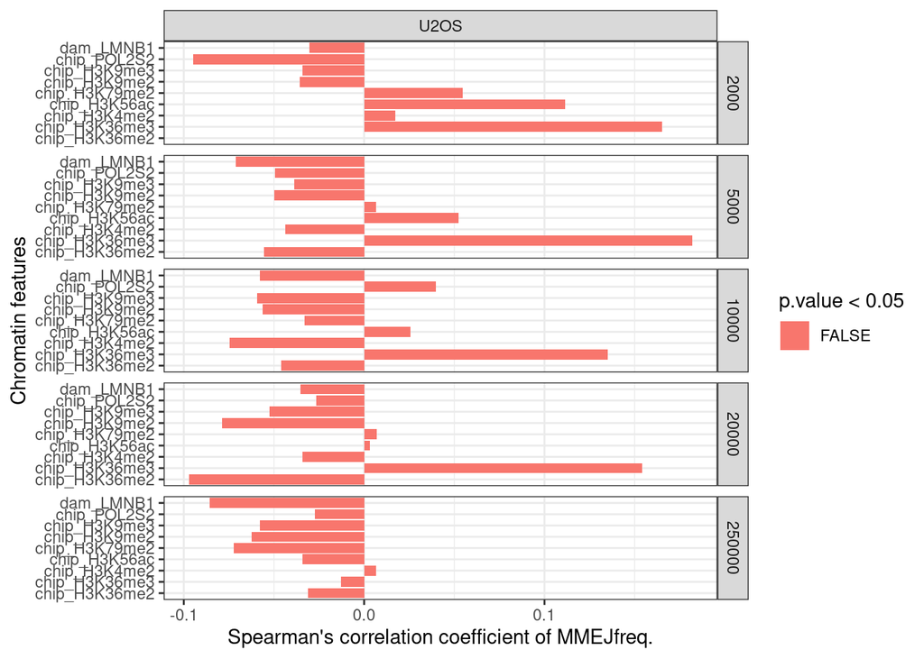

```r
#Calculate spearman correlation for all chromatin features
cell_lines <- c("U2OS")
binsizes <- c("2000","5000","10000","20000","250000")

spearman_coefficients <- map_dfr(cell_lines, function(x){
  filter_data <- values_chromatin_U2OS %>% filter(cell_line == x)
  binsize_filter <- map_dfr(binsizes, function(y){
    bin_filter <- filter_data %>% filter(binsize == y)
    rho_table <- map_dfr(colnames(values_chromatin_U2OS[7:15]), function(j){
      balance <- bin_filter$mean_bal
      feature <- as.numeric(as.matrix(bin_filter[j]))
        cor.test(x = balance, y = feature, method = "spearman", use = "pairwise.complete.obs") %>% broom::tidy() %>% mutate(chromatin = j)
    })
  rho_table %>% mutate(cell_line = x, binsize = y) %>% distinct()
  })
})


#Plot correlation coefficients
ggplot(spearman_coefficients %>% distinct()) +
  geom_col(aes(chromatin,estimate, fill = p.value < 0.05)) +
  coord_flip() +
  theme_bw() +
  xlab("Chromatin features") +
  ylab("Spearman's correlation coefficient of MMEJfreq.") +
  facet_grid(fct_relevel(binsize,binsizes)~ fct_relevel(cell_line, c("RPE1","RPEPro","RPEDef")))
```

#Join with balances and calculate the correlation (do this for all marks) = Pearson’s

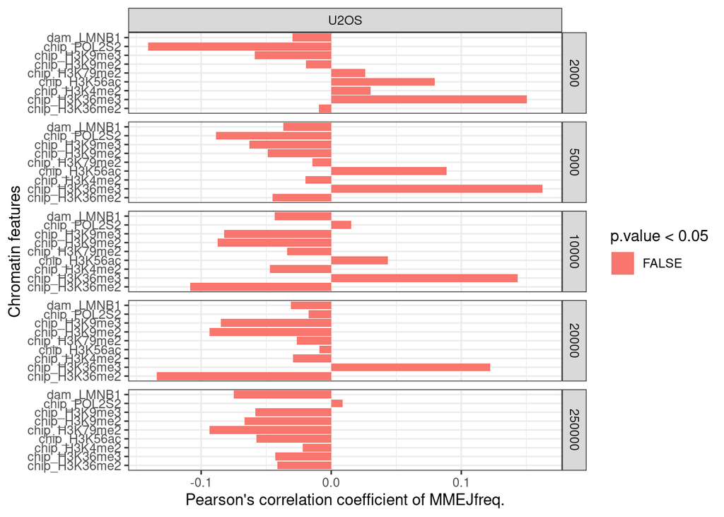

```r
pearson_coefficients <- map_dfr(cell_lines, function(x){
  filter_data <- values_chromatin_U2OS %>% filter(cell_line == x)
  binsize_filter <- map_dfr(binsizes, function(y){
    bin_filter <- filter_data %>% filter(binsize == y)
    rho_table <- map_dfr(colnames(values_chromatin_U2OS[7:15]), function(j){
      balance <- bin_filter$mean_bal
      feature <- as.numeric(as.matrix(bin_filter[j]))
        cor.test(x = balance, y = feature, method = "pearson", use = "pairwise.complete.obs") %>% broom::tidy() %>% mutate(chromatin = j)
    })
  rho_table %>% mutate(cell_line = x, binsize = y) %>% distinct()
  })
})

#Plot correlation coefficients
ggplot(pearson_coefficients %>% distinct()) +
  geom_col(aes(chromatin,estimate, fill = p.value < 0.05)) +
  coord_flip() +
  theme_bw() +
  xlab("Chromatin features") +
  ylab("Pearson's correlation coefficient of MMEJfreq.") +
  facet_grid(fct_relevel(binsize,binsizes)~ fct_relevel(cell_line, c("RPE1","RPEPro","RPEDef")))
```

#Conclusion: In U2OS, there is no correlation between chromatin features and MMEJ frequency. I will check if this is the case for TIF

#Join with balances and calculate the correlation with TIF (do this for all marks) = Pearson’s

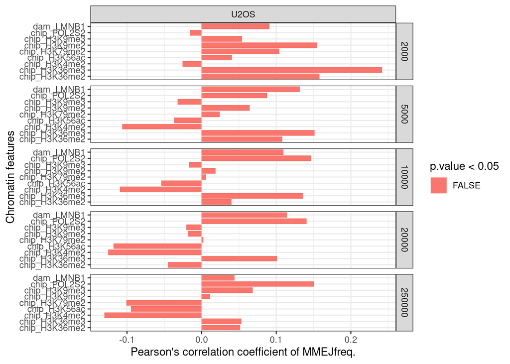

```r
pearson_coefficients_TIF <- map_dfr(cell_lines, function(x){
  filter_data <- values_chromatin_U2OS %>% filter(cell_line == x)
  binsize_filter <- map_dfr(binsizes, function(y){
    bin_filter <- filter_data %>% filter(binsize == y)
    rho_table <- map_dfr(colnames(values_chromatin_U2OS[7:15]), function(j){
      balance <- bin_filter$mean_TIF
      feature <- as.numeric(as.matrix(bin_filter[j]))
        cor.test(x = balance, y = feature, method = "pearson", use = "pairwise.complete.obs") %>% broom::tidy() %>% mutate(chromatin = j)
    })
  rho_table %>% mutate(cell_line = x, binsize = y) %>% distinct()
  })
})

#Plot correlation coefficients
ggplot(pearson_coefficients_TIF %>% distinct()) +
  geom_col(aes(chromatin,estimate, fill = p.value < 0.05)) +
  coord_flip() +
  theme_bw() +
  xlab("Chromatin features") +
  ylab("Pearson's correlation coefficient of MMEJfreq.") +
  facet_grid(fct_relevel(binsize,binsizes)~ fct_relevel(cell_line, c("RPE1","RPEPro","RPEDef")))
```

Conclusion: There’s nothing with TIF as well. There are other confounding factors, we will wait for higher quality data. But, most likely we cannot use this cell line.

#Export U2OS data

```r
#Export log2 chromatin data for RPE1
write_rds(chromatin_pools_binsize, file = "~/XV_P3_ChromDSBScreen/xv_CRISPR_screen_figures/data/revisions/pools_balance/xv20230814_chromatin_features_zscore_U2OS.rds")
```